# Activity 10: Geographic Information System

Jerome Poblete

2026-06-22

# A. Retrieving spatial data

## 1. In RStudio, create an R Markdown file. Name it “Your Surname_gis.rmd.”

You’re looking at it right now!

## 2. Go to the Global Biodiversity Information Facility (GBIF) website.

Create your account and download your assigned species records below as a CSV file (see Table).

The taxon information for *Barbourula busuangensis* can be found [here](https://www.gbif.org/taxon/KMPP).

## 3. Clean the data by removing records found outside the reported species range.

```r
library(tidyverse) # install.packges("tidyverse")

# This is the same as `cleaned` in `act10_gis.R`.
gbif.raw <- utils::read.delim("../data/Barbourula_busuangensis_GBIF.csv")
gbif <- gbif.raw |>
  ## TODO: Almost all the entries are what we need, but some are missing
  ##       named location data. Do we want to filter them out?
  # dplyr::filter(!(stateProvince %in% c("", "#nd"))) |>
  dplyr::select(decimalLatitude:decimalLongitude)

# Remove rows containing NA's.
gbif <- gbif[gbif |> complete.cases(), ]
```

## 4. Go to the DIVA-GIS website and download the Philippine administrative boundaries/areas.

The zip file contains multiple shapefiles (adm0–3), representing different boundary levels (0-country; 1-provincial; 2-municipal; 3-barangay).

## 5. Get only the provincial level.

Subset the provinces that contain only distribution records for your assigned species.

```r
# install.packages(c("sf", "terra"))
library(sf)
library(terra)

pal <- sf::st_read("../data/PHL_adm/PHL_adm1.shp") |>
  dplyr::filter(NAME_1 == "Palawan") |>
  dplyr::select(geometry)
# x=Longitude, y=Latitude
bounds <- pal |> terra::ext()

# Remove the one outlier from Luzon.
gbif <- gbif |> dplyr::filter(
  dplyr::between(decimalLongitude, bounds$xmin, bounds$xmax),
  dplyr::between(decimalLatitude,  bounds$ymin, bounds$ymax))
```

## 6. Go back to the DIVA-GIS website.

Download the Philippine digital elevation model (“Elevation [country mask]”), then clip it using the provinces you selected in step 5.

```r
phil_dem <- terra::rast("../data/ph_ strm_geo.tif")

## Transform if needed.
pal <- pal |> sf::st_transform(phil_dem |> st_crs())

## Clip raster.
dem <- phil_dem |> crop(pal) |> mask(pal)
```

## 7. (Optional) Is the DIVA-GIS is acting weirdly?

If so, you can download the admin boundaries [here](https://dlsu.instructure.com/courses/249254/files/32290423?wrap=1) and elevation [here](https://dlsu.instructure.com/courses/249254/files/32290449?wrap=1).

# B. Create your first map

## 1. Now, put all the data together into a map, following the pre-lab lecture.

Make sure that data layers (points, polygons, DEMs) are arranged properly. Be creative!)

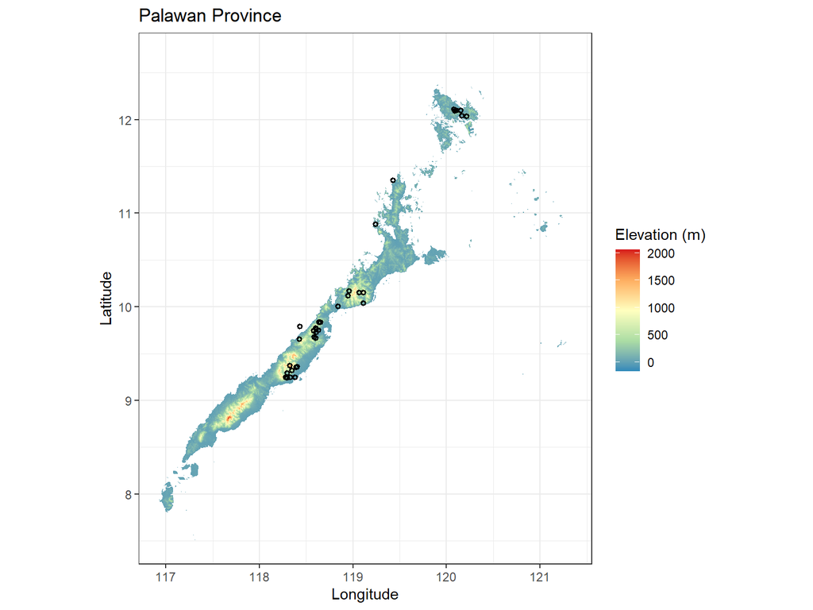

```r
# install.packages(c("ggplot2", "ggnewscale"))
library(ggplot2)
library(ggnewscale)

## Convert demarcation(?) data for ggplot.
names(dem) <- "elevation"

## Visualize the lowest to highest points.
gradient <- c("#2B89BA", "#ABDDA4", "#FFFFBF", "#FDAE61", "#D7191C")

## Plot DEM.
ggplot2::ggplot(terra::as.data.frame(dem, xy = TRUE)) +
  ggplot2::geom_tile(aes(x, y, fill=elevation)) +

  ## Change color manually.
  ggplot2::scale_fill_gradientn(colors=gradient, name="Elevation (m)") +

  ## Plot sampling points as well.
  ggnewscale::new_scale_fill() +
  ggplot2::geom_point(data=gbif, # Override the implicit argument!
    mapping = aes(decimalLongitude, decimalLatitude),
    shape   = 21,
    color   = "black",
    size    = 1.0,
    stroke  = 1.0) +

  ## Finalization.
  ggplot2::coord_equal() +
  ggplot2::labs(title="Palawan Province", x="Longitude", y="Latitude") +
  ggplot2::theme_bw()
```

```r
## Save the previous ggplot plot to a PDF file.
ggplot2::ggsave("Barbourule_busuangensis.pdf")
```